# Import Stroop Data

```python
import pandas as pd
s = pd.read_csv('stroopdata.csv', decimal=".")
s['Delta'] = s['Incongruent'] - s['Congruent']
s.head()
```

|  | Congruent | Incongruent | Delta |
| --- | --- | --- | --- |
| 0 | 12.079 | 19.278 | 7.199 |
| 1 | 16.791 | 18.741 | 1.950 |
| 2 | 9.564 | 21.214 | 11.650 |
| 3 | 8.630 | 15.687 | 7.057 |
| 4 | 14.669 | 22.803 | 8.134 |

# References

[Udacity Course Material](http://www.udacity.com)

[Wikipedia](http://www.wikipedia.org)

[stackoverflow](http://www.stackoverflow.com)

[Stroop Effect](https://faculty.washington.edu/chudler/words.html#seffect)

[Paired t-test](http://influentialpoints.com/Training/paired_t-test-principles-properties-assumptions.htm)

[Assumption of Normality](http://www2.psychology.uiowa.edu/faculty/mordkoff/GradStats/part%201/I.07%20normal.pdf)

# Variables - Question 1

dependent variable: difference between test times for congruent and incongruent tests

independent variable: test setup (congruent, incongruent)

# Hypothesis Tests - Question 2

The null hypothesis used is:

> H<sub>0</sub>: Both tests, with congruent colors and incongruent colors take the same average time to answer

This corresponds to

> µ<sub>congruent</sub> $=$ µ<sub>incongruent</sub>  
> or µ<sub>delta</sub> $=$ 0

where µ<sub>x</sub> is the respective population mean

The alternative hypothesis is:

> H<sub>a</sub>: The test with incongruent colors takes a different average time to answer

This corresponds to

> µ<sub>congruent</sub> $\neq$ µ<sub>incongruent</sub>  
> or µ<sub>delta</sub> $\neq$ 0

where µ<sub>x</sub> is the respective population mean

We have a small sample size and the population parameters are unknown. Hence, we can't compute the z-statistic. I will use the t-statistic instead. Intuition suggests, that the average time to answer the incongruent test should be longer, than the average time taken for the congruent test. However, as we can't be certain, that this is the case, a two-tailed t-test is chosen. There are two dependent samples, for the congruent and the incongruent test. Therefore, I conduct a

> two tailed dependent t-test for paired samples

The following assumptions are made for this kind of test:

1. The differences of the means are taken from measured (analogue) values
   - In our case is true, because we compare time differences measured in seconds
2. Sampling is random and pairs of observation are independent
   - This can be assumed, since the test is taken online, without the participants being normally influenced by each other
3. The distribution of mean differences across samples is normal
   - According to the Central Limit Theorem, the distribution of the sample means approaches a normal distribution for a large sample size

# Descriptive Statistics - Question 3

```python
s.describe()
```

|  | Congruent | Incongruent | Delta |
| --- | --- | --- | --- |
| count | 24.000000 | 24.000000 | 24.000000 |
| mean | 14.051125 | 22.015917 | 7.964792 |
| std | 3.559358 | 4.797057 | 4.864827 |
| min | 8.630000 | 15.687000 | 1.950000 |
| 25% | 11.895250 | 18.716750 | 3.645500 |
| 50% | 14.356500 | 21.017500 | 7.666500 |
| 75% | 16.200750 | 24.051500 | 10.258500 |
| max | 22.328000 | 35.255000 | 21.919000 |

The average time taken by test participants for congruent colors is approximately 14 seconds, whereas the average time taken by participants for the incongruent colors is approximately 22 seconds. Even the minimum difference between both tests by all participants in the sample is approximately 2 seconds. No participant has completed the test with incongruent colors in a shorter time than for congruent colors.

# Visualization - Question 4

```
array([[<matplotlib.axes._subplots.AxesSubplot object at 0x000000000A9DB128>,
        <matplotlib.axes._subplots.AxesSubplot object at 0x000000000AB7D518>]], dtype=object)
```

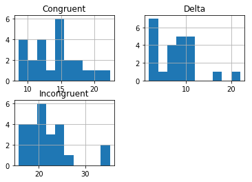

```python
s.hist()
```

The plots above show the histograms for the times taken by participants of the Stroop test in seconds, when being shown congruent colors and incongruent colors as well as the difference between both times (Delta). As we can see, the distributions are anything but normal. All distributions are positively skewed, with values as shown in the cell below.

When increasing the sample size, the distribution of the differences approaches a normal distribution according to the Central Limit Theorem, even if the individual populations for the congruent and the incongruent tests are not normally distributed.

```python
s.skew()
```

```
Congruent      0.41690
Incongruent    1.54759
Delta          1.07321
dtype: float64
```

## Statistical Test - Question 5

The following statistics are determined in order to determine, if the null hypothesis can be rejected or not:

t-statistic: sampling distribution, when population parameters are estimated using the sample properties

> The t-statistic is calculated based on the difference between the average times, participants have taken for congruent and incongruent tests

alpha level: level of confidence for the statitical test

> the alpha level can be chosen to reflect the expected confidence level. Typical alpha levels are 0.05, 0.001 and 0.001. These represent confidence levels of 95%, 99% and 99.9% respectively.

confidence interval: interval of results corresponding to the chosen alpha level

> the test result lies within the confidence interval with a level of confidence as defined by the alpha level

Cohen's D: effect size in standard deviations

> The effect in this case is the change in test time between congruent and incongruent tests

R<sup>2</sup>: proportion of the variance of the dependent variable, that can be explained by the variance of the independent variable

> remember, the dependent variable is the delta of test times, the independent variable is the test setup (congruent, incongruent)

```python
# determine all necessary sample parameters in order to calculate the t-statistic and Cohen's D and r squared

# number of samples n
n = len(s['Delta'])
# degrees of freedom df
df = n-1
# mean delta mud
mud = s['Delta'].mean()
# sample standard deviation S
S = s['Delta'].std()

# calculate the t-statistic t
t = mud / (S/n**0.5)
# calculate Cohen's D
D = mud/S
# calculate r squared
r2 = t**2/(t**2 + df)

print 'degrees of freedom: ' + str(df)
print 't-statistic: ' + str(round(t,2))
print 'Cohen\'s D: ' + str(round(D,2))
print 'r squared: ' + str(round(r2,2))
```

```
degrees of freedom: 23
t-statistic: 8.02
Cohen's D: 1.64
r squared: 0.74
```

```python
# define alpha level
alpha = 0.001
# lookup t-critical for alpha = 0.01, df = 23 and a two-tailed test in t-table
tcritical = 2.807

# calculate confidence interval CI
CIlower = mud - tcritical*(S/n**0.5)
CIupper = mud + tcritical*(S/n**0.5)
CI = (round(CIlower,2),round(CIupper,2))

print 'Confidence interval for the average difference between both tests\n\nCI: ' + str(CI)
```

```
Confidence interval for the average difference between both tests

CI: (5.18, 10.75)
```

R<sup>2</sup> is 0.74, which means, that most of the variance of the difference in test times can be explained by the variance of the test setup itself (congruent and incongruent tests)

# Conclusion - Question 6

It can be shown that when showing participants words of colors in congruently colored letters, these words can be read in significantly shorter time than when the colors and the words do not match as in the incongruent test. This might be due to the way the brain handles the recognition of words. We might have a certain preconception of what a word should look like and are confused, when the actual situation is different.

It would be intersting to have a child that can distinguish colors but can't read yet to take this test and see if the times are more even as I would expect.

I will try this on my 5 year old son right away :-)